# Final Test

## Q1

From the dataset `heights` in the `dslabs` package, please describe the distribution of male and female heights. If you pick a female at random, what is the probability that she is 61 inches or shorter?

```r
library(dslabs)
data(heights)

head(heights)
```

|  | sex | height |
| --- | --- | --- |
| 1 | Male | 75 |
| 2 | Male | 70 |
| 3 | Male | 68 |
| 4 | Male | 74 |
| 5 | Male | 61 |
| 6 | Female | 65 |

```r
heights %>% group_by(sex) %>% summarize(mean = mean(height), sd = sd(height), n= n())
```

| sex | mean | sd | n |
| --- | --- | --- | --- |
| Female | 64.93942 | 3.760656 | 238 |
| Male | 69.31475 | 3.611024 | 812 |

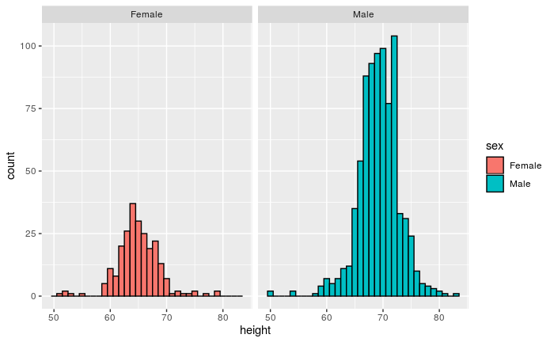

```r
heights %>% ggplot(aes(x=height, fill = sex)) +
  geom_histogram(binwidth = 1, col = 'black') +
  facet_wrap(sex ~.)
```

두 집단의 분포는 위와 같이 나타낼 수 있다.

평균은 남성이 여성보다 5 inch 정도 더 높고, 표준편차는 두 집단사이에 큰 차이가 없었다. 두 집단 모두 평균 근처에서 가장 높고, 좌우 극단으로 갈 수록 사람수가 감소하는 분포를 가지고 있었다. 따라서 자연에서 자주 관찰되는 정규분포로 가정해볼 수 있다.

```r
heights %>% filter(sex == "Female") %>% summarize(a=mean(height <= 61)) %>% pull(a)
```

```
[1] 0.1218487
```

```r
pnorm(61, 64.94, 3.76)
```

```
[1] 0.1473487
```

실제 61인치 이하 여성은 12.1%이고, 정규분포로 근사한 61인치 이하 여성의 비율은 14.7%로 2%p의 차이를 보임을 알 수 있다.

## Q2

For American Roulette, there are 19 reds, 16 blacks and 3 greens. The payout for winning on green is 15 dollars. You create a random variable that is the sum of your winnings after betting on green 1000 times. Start your code by setting the seed to 1. Describe your random variable (e.g. the expected value, the standard error). Then, create a Monte Carlo simulation that generates 1,000 outcomes of a random variable, and then describe your result.

```r
p = 35/38
N = 1000
# set.seed(1)
X <- replicate(N, sample(c(-1, 15), 1, prob=c(p, 1-p)))
sum(X)
```

```
[1] 424
```

```r
sd(X)
```

```
[1] 4.55818
```

```r
ev = (-1*p+15*(1-p))*N
se = (15-(-1))*sqrt(N*p*(1-p))
ev
```

```
[1] 263.1579
```

```r
se
```

```
[1] 136.4366
```

```r
set.seed(1)

p = 35/38
N = 1000
B = 1000
X <- replicate(B, {
  X <- replicate(N, sample(c(-1, 15), 1, prob=c(p, 1-p)))
  return(sum(X))
})
mean(X)
```

```
[1] 257.024
```

```r
sd(X)
```

```
[1] 138.0665
```

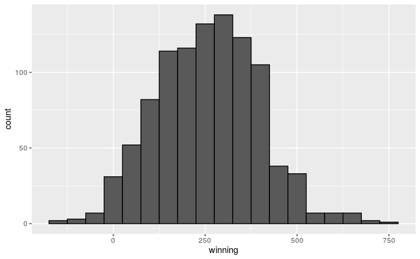

```r
data.frame(winning = X) %>%
  ggplot(aes(x=winning)) +
  geom_histogram(binwidth = 50, col = 'black')
```

winning을 1000번 나타냈을 때, 가운데가 가장 높고 양 끝으로 갈 수록 적어지는 분포를 보인다. 하지만 이는 정규분포는 아니다. 좌우가 대칭이 되지 않고 다소 낮은 값에 쏠림을 알 수 있다. 이는 두 결과값이 차이가 크기 때문에 (-1과 15) 정규분포에 대한 근사가 완벽하게 되지 않고, 오차가 발생할 수 있다. 하지만 실제 기댓값, 표준 오차가 이론값과 비슷하므로 CLT이 들어맞는다고 할 수 있지만, 다른 모델을 구상하는 것이 좋을 것이다.

## Q3

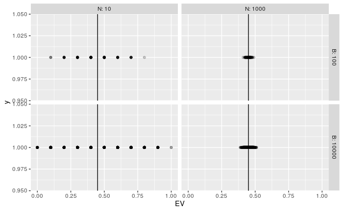

주어진 조건대로 가상의 설문조사를 진행한 결과를 나타내면 위와 같다. N 즉, 한 설문조사에서 몇 명을 조사했는지를 나타내는 데, N이 커질 수록 실젯값 p=0.45에 가까이 분포하는 것을 알 수 있다. 또한 B 즉, 설문조사 횟수를 늘릴 수록 더 극단적인 값이 나타나는 경우의 수가 늘어나서 분포가 더 멀어진다. 따라서 N과 B는 늘어날 수록 더 정확한 값을 얻는데 도움이 되지만, B값을 늘리는 경우에는 극단적인 값이 늘어나므로 주의할 필요가 있을 것이다.